# STATS 7022 - Data Science Assignment 2: Question 1

Dongju Ma

Trimester 1, 2025

# 1 Load Libraries

```r
pacman::p_load(dplyr, tidymodels)
```

# 2 Load Data

The data is contained within the file `bird_bath.rds` . The data is read in to R .

```r
bird_bath <- readRDS("./data/bird_bath.rds")
bird_bath
```

```
## # A tibble: 161,057 × 5
##    survey_year urban_rural bioregions               bird_type         bird_count
##          <dbl> <chr>       <chr>                    <chr>                  <dbl>
##  1        2014 Urban       South Eastern Queensland Bassian Thrush             0
##  2        2014 Urban       South Eastern Queensland Chestnut-breaste…          0
##  3        2014 Urban       South Eastern Queensland Wild Duck                  0
##  4        2014 Urban       South Eastern Queensland Willie Wagtail             0
##  5        2014 Urban       South Eastern Queensland Regent Bowerbird           0
##  6        2014 Urban       South Eastern Queensland Rufous Fantail             0
##  7        2014 Urban       South Eastern Queensland Spiny-cheeked Ho…          0
##  8        2014 Urban       South Eastern Queensland Flame Robin                0
##  9        2014 Urban       South Eastern Queensland European Goldfin…          0
## 10        2014 Urban       South Eastern Queensland Noisy Friarbird            0
## # ℹ 161,047 more rows
```

There are 161,057 rows in the `bird_bath` data.

# 3 Data Cleanning

## 3.1 Remove Missing Years

Some rows are missing a survey year ( `survey_year` ). These rows are removed from the data.

```r
bird_bath <- bird_bath %>% na.omit(survey_year)
bird_bath
```

```
## # A tibble: 160,888 × 5
##    survey_year urban_rural bioregions               bird_type         bird_count
##          <dbl> <chr>       <chr>                    <chr>                  <dbl>
##  1        2014 Urban       South Eastern Queensland Bassian Thrush             0
##  2        2014 Urban       South Eastern Queensland Chestnut-breaste…          0
##  3        2014 Urban       South Eastern Queensland Wild Duck                  0
##  4        2014 Urban       South Eastern Queensland Willie Wagtail             0
##  5        2014 Urban       South Eastern Queensland Regent Bowerbird           0
##  6        2014 Urban       South Eastern Queensland Rufous Fantail             0
##  7        2014 Urban       South Eastern Queensland Spiny-cheeked Ho…          0
##  8        2014 Urban       South Eastern Queensland Flame Robin                0
##  9        2014 Urban       South Eastern Queensland European Goldfin…          0
## 10        2014 Urban       South Eastern Queensland Noisy Friarbird            0
## # ℹ 160,878 more rows
```

There are now 160,888 rows in the `bird_bath` data.

## 3.2 Identify the Top 15 Types of Bird

We consider only the top 15 bird species ( `bird_type` ) by frequency ( `bird_count` ). Results are summarised in Table 3.1.

```r
top_15_birds <- filter(bird_bath, bird_count == 1)%>%
  count(bird_type, sort = TRUE) %>%
  slice_head(n = 15)

top_15_birds %>%
  knitr::kable(caption = "Top 15 birds at Australian bird baths, by frequency.") %>%
  kable_styling(full_width = TRUE)
```

Table 3.1: Top 15 birds at Australian bird baths, by frequency.

| bird_type | n |
| --- | --- |
| Noisy Miner | 292 |
| Australian Magpie | 262 |
| Rainbow Lorikeet | 235 |
| Red Wattlebird | 171 |
| Superb Fairy-wren | 170 |
| Magpie-lark | 160 |
| Pied Currawong | 157 |
| Crimson Rosella | 155 |
| Eastern Spinebill | 153 |
| Spotted Dove | 151 |
| Lewin’s Honeyeater | 133 |
| Satin Bowerbird | 131 |
| Crested Pigeon | 125 |
| Grey Fantail | 123 |
| Red-browed Finch | 117 |

```r
bird_bath <- bird_bath %>%
  filter(bird_type %in% top_15_birds$bird_type)
bird_bath
```

```
## # A tibble: 14,280 × 5
##    survey_year urban_rural bioregions               bird_type         bird_count
##          <dbl> <chr>       <chr>                    <chr>                  <dbl>
##  1        2014 Urban       South Eastern Queensland Satin Bowerbird            0
##  2        2014 Urban       South Eastern Queensland Eastern Spinebill          0
##  3        2014 Urban       South Eastern Queensland Red Wattlebird             0
##  4        2014 Urban       South Eastern Queensland Crimson Rosella            0
##  5        2014 Urban       South Eastern Queensland Australian Magpie          0
##  6        2014 Urban       South Eastern Queensland Pied Currawong             0
##  7        2014 Urban       South Eastern Queensland Magpie-lark                0
##  8        2014 Urban       South Eastern Queensland Crested Pigeon             0
##  9        2014 Urban       South Eastern Queensland Lewin's Honeyeat…          0
## 10        2014 Urban       South Eastern Queensland Superb Fairy-wren          0
## # ℹ 14,270 more rows
```

There are now 14,280 rows in the `bird_bath` data.

## 3.3 Create the Response Variable

We define a new response variable, called `bird_present` , using the following rule:

- If `bird_count` is greater than zero for a row, then `bird_present` takes value “yes”,
- Otherwise, `bird_present` takes value “no”.

```r
bird_bath <- bird_bath %>%
  mutate(bird_present = ifelse(bird_count > 0, "yes", "no"))
bird_bath
```

```
## # A tibble: 14,280 × 6
##    survey_year urban_rural bioregions          bird_type bird_count bird_present
##          <dbl> <chr>       <chr>               <chr>          <dbl> <chr>
##  1        2014 Urban       South Eastern Quee… Satin Bo…          0 no
##  2        2014 Urban       South Eastern Quee… Eastern …          0 no
##  3        2014 Urban       South Eastern Quee… Red Watt…          0 no
##  4        2014 Urban       South Eastern Quee… Crimson …          0 no
##  5        2014 Urban       South Eastern Quee… Australi…          0 no
##  6        2014 Urban       South Eastern Quee… Pied Cur…          0 no
##  7        2014 Urban       South Eastern Quee… Magpie-l…          0 no
##  8        2014 Urban       South Eastern Quee… Crested …          0 no
##  9        2014 Urban       South Eastern Quee… Lewin's …          0 no
## 10        2014 Urban       South Eastern Quee… Superb F…          0 no
## # ℹ 14,270 more rows
```

## 3.4 Select Columns

We only need the following columns:

- `urban_rural`
- `bird_type`
- `bird_present`

```r
bird_bath <- bird_bath %>%
  select(urban_rural, bird_type, bird_present)
bird_bath
```

```
## # A tibble: 14,280 × 3
##    urban_rural bird_type          bird_present
##    <chr>       <chr>              <chr>
##  1 Urban       Satin Bowerbird    no
##  2 Urban       Eastern Spinebill  no
##  3 Urban       Red Wattlebird     no
##  4 Urban       Crimson Rosella    no
##  5 Urban       Australian Magpie  no
##  6 Urban       Pied Currawong     no
##  7 Urban       Magpie-lark        no
##  8 Urban       Crested Pigeon     no
##  9 Urban       Lewin's Honeyeater no
## 10 Urban       Superb Fairy-wren  no
## # ℹ 14,270 more rows
```

All other columns are removed.

## 3.5 Convert Variables to Categorical

We convert all remaining variables to categorical variables.

```r
bird_bath <- bird_bath %>%
  mutate_all(factor)
bird_bath
```

```
## # A tibble: 14,280 × 3
##    urban_rural bird_type          bird_present
##    <fct>       <fct>              <fct>
##  1 Urban       Satin Bowerbird    no
##  2 Urban       Eastern Spinebill  no
##  3 Urban       Red Wattlebird     no
##  4 Urban       Crimson Rosella    no
##  5 Urban       Australian Magpie  no
##  6 Urban       Pied Currawong     no
##  7 Urban       Magpie-lark        no
##  8 Urban       Crested Pigeon     no
##  9 Urban       Lewin's Honeyeater no
## 10 Urban       Superb Fairy-wren  no
## # ℹ 14,270 more rows
```

# 4 Models

We create two separate workflows using `tidymodels` :

1. A logistic regression model with `bird_present` as the response variable and urban_rural and bird_type as the predictors

```r
bird_bath_recipe1 <- recipe(bird_present ~ urban_rural + bird_type, data = bird_bath) %>%
  step_dummy()

bird_bath_model1 <- logistic_reg() %>%
  set_mode("classification") %>%
  set_engine("glm")

bird_bath_wf1 <- workflow() %>%
  add_recipe(bird_bath_recipe1) %>%
  add_model(bird_bath_model1)
bird_bath_wf1
```

```
## ══ Workflow ════════════════════════════════════════════════════════════════════
## Preprocessor: Recipe
## Model: logistic_reg()
##
## ── Preprocessor ────────────────────────────────────────────────────────────────
## 1 Recipe Step
##
## • step_dummy()
##
## ── Model ───────────────────────────────────────────────────────────────────────
## Logistic Regression Model Specification (classification)
##
## Computational engine: glm
```

2. A logistic regression model with the same predictors and response, plus a two-way interaction between `urban_rural` and bird_type

```r
bird_bath_recipe2 <- recipe(bird_present ~ urban_rural + bird_type, data = bird_bath) %>%
  step_dummy() %>%
  step_interact(bird_present ~ urban_rural:bird_type)

bird_bath_model2 <- logistic_reg() %>%
  set_mode("classification") %>%
  set_engine("glm")

bird_bath_wf2 <- workflow() %>%
  add_recipe(bird_bath_recipe2) %>%
  add_model(bird_bath_model2)
bird_bath_wf2
```

```
## ══ Workflow ════════════════════════════════════════════════════════════════════
## Preprocessor: Recipe
## Model: logistic_reg()
##
## ── Preprocessor ────────────────────────────────────────────────────────────────
## 2 Recipe Steps
##
## • step_dummy()
## • step_interact()
##
## ── Model ───────────────────────────────────────────────────────────────────────
## Logistic Regression Model Specification (classification)
##
## Computational engine: glm
```

Both models are fitted to the `bird_bath` data, with ROC curves displayed in Figure 5.1

# 5 ROC Curves

```r
bird_bath_fit1 <- bird_bath_wf1 %>%
  fit(bird_bath)

bird_bath_fit2 <- bird_bath_wf2 %>%
  fit(bird_bath)
```

```r
bird_bath_pred1 <- bird_bath %>%
  bind_cols(predict(bird_bath_fit1, bird_bath),
            predict(bird_bath_fit1, bird_bath, type = "prob")) %>%
  select(bird_present, starts_with(".pred"))

bird_bath_pred2 <- bird_bath %>%
  bind_cols(predict(bird_bath_fit2, bird_bath),
            predict(bird_bath_fit2, bird_bath, type = "prob")) %>%
  select(bird_present, starts_with(".pred"))

roc_1 <- bird_bath_pred1 %>%
  roc_curve(truth = bird_present, .pred_no) %>%
  mutate(model = "Model 1")

roc_2 <-  bird_bath_pred2 %>%
  roc_curve(truth = bird_present, .pred_no) %>%
  mutate(model = "Model 2")

roc_bind <- bind_rows(roc_1, roc_2) %>%
  mutate(model = factor(model, levels = c("Model 1", "Model 2")))
roc_bind
```

```
## # A tibble: 64 × 4
##    .threshold specificity sensitivity model
##         <dbl>       <dbl>       <dbl> <fct>
##  1   -Inf          0            1     Model 1
##  2      0.668      0            1     Model 1
##  3      0.701      0.0233       0.980 Model 1
##  4      0.705      0.0533       0.961 Model 1
##  5      0.731      0.145        0.925 Model 1
##  6      0.735      0.161        0.904 Model 1
##  7      0.763      0.234        0.863 Model 1
##  8      0.803      0.311        0.824 Model 1
##  9      0.804      0.325        0.802 Model 1
## 10      0.815      0.367        0.786 Model 1
## # ℹ 54 more rows
```

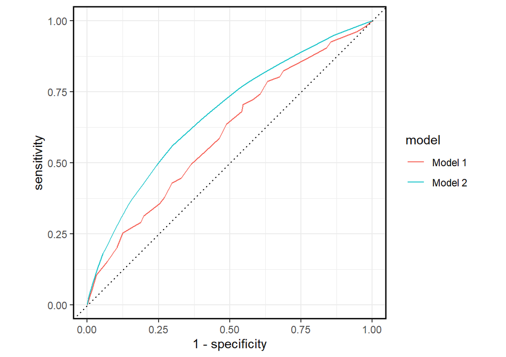

Figure 5.1: ROC curves for logisitic regression models.

```r
ggplot(roc_bind, aes(x = 1 - specificity, y = sensitivity, color = model)) +
  geom_line(linewidth = 0.5) +
  geom_abline(slope = 1, intercept = 0, linetype = "dotted") +
    scale_color_manual(values = c("Model 1" = "#F66359", "Model 2" = "#1AC5CA")) +
  labs(color = "model") +
  coord_equal() +
  theme_bw() +
  theme(
    panel.border = element_rect(color = "black", fill = NA, linewidth = 1),
    legend.position = "right"
  )
```